# Generation of DEG lists with revised methods

## Description

### v3 Description Dec. 5, 2018

V3 of this analysis code is intended to be the final major revision, updates to this revision from v2 focus on naming comparisions and files more consistently, saving all results we need to a hierarchical folder system, and clean up of un-needed code chunks.

### v2 notes

With Feedback from a meeting on Oct. 26, 2018, this analysis is updated to use more consistent parameters for defining sets of differentially expressed genes (DEGs).

The key updates are: * Use more stringent filter for genes based on level of expression * use wound control to eliminate genes before analysis to help FDR when identifying genes between S and R conditions * Use a reasonable FDR cutouff * use a consistent fold change filter

## Functions:

```r
makeFname <- function(folder, cont, change="", dtype="", FDRmax, logFCmin){
  filename <- paste(folder, "/", cont, change, dtype, "_FDR",
                    str_pad(FDRmax*100, 2, pad="0"), "_LFC",
                    str_pad(logFCmin,2, pad=0), "_",
                    format(Sys.time(), "%Y%m%d"), sep="")
  if (dtype %in% c("", "_At_homologs")){
    filename <- paste(filename, ".csv", sep="")
  } else if (grepl("plot|hist|diag", dtype)){
    filename <- paste(filename, ".png", sep="")
  } else if (dtype == "_promoters") {
    filename <- paste(filename, ".fasta", sep="")
  }
  return(filename)
}
save_DEGs <- function(DEGList, folder, cont, FDRmax, logFCmin, dir){
  DEGs <- DEGList
  DEGs$Gene_ID <- row.names(DEGs)
  DEGs <- dplyr::left_join(DEGs, edinburghGeneInfo, by="Gene_ID")
  row.names(DEGs) <- DEGs$Gene_ID

  # fname <- makeFname(folder=folder, cont=cont, FDRmax=FDRmax, logFCmin=logFCmin)
  # fPath <- file.path(dirPath, fname)
  # write.csv(DEGs, fPath, row.names=TRUE)

  upDEGs <- subset(DEGs, logFC > 0)
  downDEGs <- subset(DEGs, logFC < 0)

  fname <- makeFname(folder=folder, cont=cont, change="_UP", FDRmax=FDRmax, logFCmin=logFCmin)
  fPath <- file.path(dirPath, fname)
  write.csv(upDEGs, fPath, row.names=TRUE)

  fname <- makeFname(folder=folder, cont=cont, change="_DOWN", FDRmax=FDRmax, logFCmin=logFCmin)
  fPath <- file.path(dirPath, fname)
  write.csv(downDEGs, fPath, row.names=TRUE)

  fname <- makeFname(folder=paste(folder, "/GO_lists", sep=""), cont=cont,
                     change="_UP", dtype="_At_homologs", FDRmax=FDRmax, logFCmin=logFCmin)
  fPath <- file.path(dirPath, fname)
  write.table(subset(upDEGs, (!is.na(Symbol)), select="A._thaliana_best_hit"),
              fPath, quote=FALSE, row.names=FALSE, na="", col.names=FALSE, sep=",")

  fname <- makeFname(folder=paste(folder, "/GO_lists", sep=""), cont=cont,
                     change="_DOWN", dtype="_At_homologs", FDRmax=FDRmax, logFCmin=logFCmin)
  fPath <- file.path(dirPath, fname)
  write.table(subset(downDEGs, (!is.na(Symbol)), select="A._thaliana_best_hit"),
              fPath, quote=FALSE, row.names=FALSE, na="", col.names=FALSE, sep=",")


  fname <- makeFname(folder=paste(folder, "/promoters", sep=""), cont=cont,
                     change="_UP", dtype="_promoters", FDRmax=FDRmax, logFCmin=logFCmin)
  fPath <- file.path(dirPath, fname)
  writeXStringSet(allPromoters2[names(allPromoters) %in% upDEGs$Gene_ID], file.path(dirPath, fname))

  fname <- makeFname(folder=paste(folder, "/promoters", sep=""), cont=cont,
                     change="_DOWN", dtype="_promoters", FDRmax=FDRmax, logFCmin=logFCmin)
  fPath <- file.path(dirPath, fname)
  writeXStringSet(allPromoters2[names(allPromoters) %in% downDEGs$Gene_ID], file.path(dirPath, fname))

}
save_Venn_Lists <- function(allGenesList, folder, cont, FDRmax, logFCmin, change, dir){
  # AllGenesList should have edinInfo, and group columns
  # change should be of form "_UP", or "_DOWN"

  allGenesList$Gene_ID <- row.names(allGenesList)

  # WT significant:
  fname <- makeFname(folder=folder, cont=paste(cont, "WT_SIG", sep="_"),
                     change=change, FDRmax=FDRmax, logFCmin=logFCmin)
  fPath <- file.path(dirPath, fname)
  write.csv(subset(allGenesList, group=="WT_sig"), fPath, row.names=TRUE)

  fname <- makeFname(folder=paste(folder, "/GO_lists", sep=""),
                     cont=paste(cont, "WT_SIG", sep="_"),
                     change=change, dtype="_At_homologs", FDRmax=FDRmax, logFCmin=logFCmin)
  fPath <- file.path(dirPath, fname)
  write.table(subset(allGenesList, (group=="WT_sig")&(!is.na(Symbol)),
                     select="A._thaliana_best_hit"),
              fPath, quote=FALSE, row.names=FALSE, na="", col.names=FALSE, sep=",")

  fname <- makeFname(folder=paste(folder, "/promoters", sep=""),
                     cont=paste(cont, "WT_SIG", sep="_"),
                     change=change, dtype="_promoters", FDRmax=FDRmax, logFCmin=logFCmin)
  fPath <- file.path(dirPath, fname)
  writeXStringSet(allPromoters2[names(allPromoters) %in% row.names(allGenesList[allGenesList$group == "WT_sig", ])], file.path(dirPath, fname))

  # phyB significant:
  fname <- makeFname(folder=folder, cont=paste(cont, "phyB_SIG", sep="_"),
                     change=change, FDRmax=FDRmax, logFCmin=logFCmin)
  fPath <- file.path(dirPath, fname)
  write.csv(subset(allGenesList, group=="phyB_sig"), fPath, row.names=TRUE)

  fname <- makeFname(folder=paste(folder, "/GO_lists", sep=""),
                     cont=paste(cont, "phyB_SIG", sep="_"),
                     change=change, dtype="_At_homologs", FDRmax=FDRmax, logFCmin=logFCmin)
  fPath <- file.path(dirPath, fname)
  write.table(subset(allGenesList, (group=="phyB_sig")&(!is.na(Symbol)),
                     select="A._thaliana_best_hit"),
              fPath, quote=FALSE, row.names=FALSE, na="", col.names=FALSE, sep=",")

  fname <- makeFname(folder=paste(folder, "/promoters", sep=""),
                     cont=paste(cont, "phyB_SIG", sep="_"),
                     change=change, dtype="_promoters", FDRmax=FDRmax, logFCmin=logFCmin)
  fPath <- file.path(dirPath, fname)
  writeXStringSet(allPromoters2[names(allPromoters) %in% row.names(allGenesList[allGenesList$group == "phyB_sig", ])], file.path(dirPath, fname))

  # both significant:
  fname <- makeFname(folder=folder, cont=paste(cont, "BOTH_SIG", sep="_"),
                     change=change, FDRmax=FDRmax, logFCmin=logFCmin)
  fPath <- file.path(dirPath, fname)
  write.csv(subset(allGenesList, group=="Both_sig"), fPath, row.names=TRUE)

  fname <- makeFname(folder=paste(folder, "/GO_lists", sep=""),
                     cont=paste(cont, "BOTH_SIG", sep="_"),
                     change=change, dtype="_At_homologs", FDRmax=FDRmax, logFCmin=logFCmin)
  fPath <- file.path(dirPath, fname)
  write.table(subset(allGenesList, (group=="Both_sig")&(!is.na(Symbol)),
                     select="A._thaliana_best_hit"),
              fPath, quote=FALSE, row.names=FALSE, na="", col.names=FALSE, sep=",")
```

```r
  fname <- makeFname(folder=paste(folder, "/promoters", sep=""),
                     cont=paste(cont, "BOTH_SIG", sep="_"),
                     change=change, dtype="_promoters", FDRmax=FDRmax, logFCmin=logFCmin)
  fPath <- file.path(dirPath, fname)
  writeXStringSet(allPromoters2[names(allPromoters) %in% row.names(allGenesList[allGenesList$group == "Both_sig", ])], file.path(dirPath, fname))

}
addWoundCtrl <- function(DEGs, woundIDs){
  output <- DEGs
  output$woundCtrl <- row.names(DEGs) %in% woundIDs
  return(output)
}
mergeGenes <- function(genesA, genesB){
  genesA$Gene_ID <- row.names(genesA)
  genesB$Gene_ID <- row.names(genesB)
  commonGenes <- dplyr::inner_join(genesA, genesB, by="Gene_ID")
  row.names(commonGenes) <- commonGenes$Gene_ID
  return(commonGenes)
}
se <- function(x){
  # calculate standard error of x
  sd(x)/sqrt(length(x))
}
group2Line <- Vectorize(function(group){
  switch(group,
         phyB.24 = 1,
         phyB.P = 1,
         phyB.R = 2,
         phyB.S = 2,
         WT.24 = 3,
         WT.P = 3,
         WT.R = 4,
         WT.S = 4)
})
plotDE <- function(geneId, normExpr, display=TRUE, save=FALSE, saveDir="", fileType="svg", title=NULL, ...){
  normExpr <- data.frame(normExpr)
  group <- gsub("_\\d_", ".", colnames(normExpr))
  geneData <- as.data.frame(t(normExpr[geneId, ]))
  geneData$group <- group
  geneData <- dplyr::group_by(geneData, group)
  dataSummary <- dplyr::summarise(geneData, mean=mean(!!rlang::sym(geneId)),
                                  SE=se(!!rlang::sym(geneId)))
  dataSummary <- tidyr::separate(dataSummary, group,
                                 into=c("Genotype", "Timepoint"), sep="[.]",
                                 remove=FALSE)
  dataSummary$Timepoint <- factor(dataSummary$Timepoint, levels=c("P", "24", "S", "R"))
  dataSummary$line <- group2Line(dataSummary$group)
  if (!is.null(title)){
    plotTitle <- title
  } else{
    plotTitle <- geneId
  }
    # make plot
  plot <- ggplot(dataSummary, aes(x=Timepoint, y=mean, color=Genotype)) + geom_point(size=2) +
    geom_errorbar(aes(ymin=mean-SE, ymax=mean+SE), width=0.2) + geom_line(aes(group=line)) +
    expand_limits(y=0) + labs(title=plotTitle, y="Relative Expression")
  if (display) {
    print(plot)
  }
  if (save) {
    if (!file.exists(saveDir)) {
      stop("the save directory does not exist")
    }
    saveFile <- file.path(saveDir, paste(geneId, " expression plot.", fileType, sep=""))
    if (file.exists(saveFile)) {
      warning(paste(saveFile, "is being overwritten"))
    }
    ggsave(saveFile, plot, device=fileType, ...)
  }
}
geneHeatmap <- function(genes, DGEdata, groupAv=TRUE, rsOnly=TRUE,
                        labels=NULL){

  DEGCpm <- cpm(DGEdata[genes, ])
  sampleOrder <- c(
    "WT_3_P",   "WT_4_P",   "WT_5_P",   "WT_6_P",
    "phyB_3_P", "phyB_4_P", "phyB_5_P",
    "WT_3_24",  "WT_4_24",  "WT_5_24",  "WT_6_24",
    "phyB_3_24","phyB_4_24","phyB_5_24",
    "WT_3_S",   "WT_4_S",   "WT_5_S",   "WT_6_S",
    "phyB_3_S", "phyB_4_S", "phyB_5_S",
    "WT_3_R",   "WT_4_R",   "WT_5_R",   "WT_6_R",
    "phyB_3_R", "phyB_4_R", "phyB_5_R",
    "WT.S_P",   "phyB.S_P", "WT.R_S",   "phyB.R_S")
  sampleOrder <- sampleOrder[sampleOrder %in% colnames(DEGCpm)]
  DEGCpm <- DEGCpm[, sampleOrder]
  group <- gsub("_\\d_", ".", colnames(DEGCpm))
  if (groupAv) {
    DEGCpm2 <- as.data.frame(t(DEGCpm))
    DEGCpm2 <- stats::aggregate(DEGCpm2, by=list(group), FUN=mean)
    row.names(DEGCpm2) <- DEGCpm2$Group.1
    DEGCpm2 <- DEGCpm2[, -1]
    DEGCpm <- t(DEGCpm2)
    groupOrder <- c("WT.P", "phyB.P", "WT.24", "phyB.24", "WT.S", "phyB.S", "WT.R", "phyB.R")
    groupOrder <- groupOrder[groupOrder %in% colnames(DEGCpm)]
    DEGCpm <- DEGCpm[, groupOrder]
  }
  if (rsOnly){
    DEGCpm <- DEGCpm[, !grepl("P|(24)", colnames(DEGCpm))]
  }
  if(!is.null(labels)) {
    hMapLabels <- labels
  } else{
    hMapLabels <- row.names(DEGCpm)
  }
  hr <- hclust(as.dist(1-cor(t(DEGCpm), method="pearson")), method="complete")
  fig <- heatmap.2(DEGCpm, dendrogram="row", Rowv=as.dendrogram(hr), trace="none",
          col="bluered", scale="row", Colv=NA, margins=c(8,7),
          labRow=hMapLabels)
  return(fig)
}
commonGenes <- function(DEGsA, DEGsB){
  commonIDs <- row.names(DEGsA)[row.names(DEGsA) %in% row.names(DEGsB)]
  DEGsA[commonIDs, ]
}
doubleVenn <- function(DEG1, DEG2, name1="Set1", name2="Set2"){
  overlap <- nrow(commonGenes(DEG1, DEG2))

  draw.pairwise.venn(area1=nrow(DEG1), area2=nrow(DEG2),
                     cross.area=overlap,
                     fill=c("red", "blue"), category=c(name1, name2))
}
tripVenn <- function(DEG1, DEG2, DEG3, names=c("Set1", "Set2", "Set3")){
  genes12 <- commonGenes(DEG1, DEG2)
  genes23 <- commonGenes(DEG2, DEG3)
  genes13 <- commonGenes(DEG1, DEG3)
  genes123 <- commonGenes(DEG1, genes23)

  draw.triple.venn(area1=nrow(DEG1), area2=nrow(DEG2), area3=nrow(DEG3),
                   n12=nrow(genes12), n23=nrow(genes23), n13=nrow(genes13),
                   n123=nrow(genes123),
                   fill=c("red", "blue", "green"), category=names, scaled=FALSE)
}
nVenn <- function(DEGsList){
  DEGVenn <- Venn(DEGsList)
  gp <- VennThemes(compute.Venn(DEGVenn))
  gp$SetText <- lapply(gp$SetText,function(x) {x$fontsize<-10; return(x)})
  plot(DEGVenn, doWeights=FALSE,gp=gp)
}
setGroup <- function(row, change="up", sigLvl=0.01, LFCutoff=1){
  if (change=="up"){
    subsetMask <- (row$logFC_WT > LFCutoff | row$logFC_phyB > LFCutoff) & (row$FDR_WT < sigLvl | row$FDR_phyB < sigLvl)
  }
  if (change=="down"){
    subsetMask <- (row$FDR_WT < sigLvl | row$FDR_phyB < sigLvl) & (row$logFC_WT < -LFCutoff | row$logFC_phyB < -LFCutoff)
  }
  wtSigTest <-row$FDR_WT < sigLvl & row$FDR_phyB > sigLvl
  phyBSigTest <- row$FDR_phyB < sigLvl & row$FDR_WT > sigLvl
  group <- "none"
  if (subsetMask) {
    group <- "sig"
    if (wtSigTest) {
      group <- "WT_sig"
    }else if (phyBSigTest) {
      group <- "phyB_sig"
    } else {
      group <- "Both_sig"
    }
  }
  return(group)
}
addAvgCpm <- function(geneList, DGEdata, groups=NULL){
```

```r
  genes <- row.names(geneList)

  DEGCpm <- cpm(DGEdata[genes, ])
  sampleOrder <- c(
    "WT_3_P",   "WT_4_P",   "WT_5_P",   "WT_6_P",
    "phyB_3_P", "phyB_4_P", "phyB_5_P",
    "WT_3_24",  "WT_4_24",  "WT_5_24",  "WT_6_24",
    "phyB_3_24","phyB_4_24","phyB_5_24",
    "WT_3_S",   "WT_4_S",   "WT_5_S",   "WT_6_S",
    "phyB_3_S", "phyB_4_S", "phyB_5_S",
    "WT_3_R",   "WT_4_R",   "WT_5_R",   "WT_6_R",
    "phyB_3_R", "phyB_4_R", "phyB_5_R",
    "WT.S_P",   "phyB.S_P", "WT.R_S",   "phyB.R_S")
  sampleOrder <- sampleOrder[sampleOrder %in% colnames(DEGCpm)]
  DEGCpm <- DEGCpm[, sampleOrder]
  if (class(DEGCpm)=="matrix") {
    group <- gsub("_\\d_", ".", colnames(DEGCpm))
    DEGCpm2 <- as.data.frame(t(DEGCpm))
  }else {
    group <- gsub("_\\d_", ".", names(DEGCpm))
    DEGCpm2 <- as.data.frame(DEGCpm)
    colnames(DEGCpm2) <- genes
  }
  DEGCpm2 <- stats::aggregate(DEGCpm2, by=list(group), FUN=mean)
  row.names(DEGCpm2) <- DEGCpm2$Group.1
  # DEGCpm2 <- DEGCpm2[, -1]
  DEGCpm <- data.frame(t(DEGCpm2))

  # row.names(DEGCpm) <- colnames(DEGCpm2)
  # colnames(DEGCpm) <- row.names(DEGCpm2)

  groupOrder <- c("WT.P", "phyB.P", "WT.24", "phyB.24", "WT.S", "phyB.S", "WT.R", "phyB.R")
  groupOrder <- groupOrder[groupOrder %in% colnames(DEGCpm)]
  DEGCpm <- DEGCpm[-1, groupOrder]
  if (!is.null(groups)){
    DEGCpm <- DEGCpm[, groups]
  }
  colnames(DEGCpm) <- paste(colnames(DEGCpm), "_Avg_CPM", sep="")
  return(cbind(geneList, DEGCpm))

}
```

## get gene Info from Edinburgh results

```r
edinburghPath <- file.path(rootDir, "data", "blast_top_hits.xlsx")
df <- read.xlsx(xlsxFile=edinburghPath, sheet=2, skipEmptyRows=FALSE)
colnames(df) <- gsub("(\\.)([a-z])", "_\\2", colnames(df))
colnames(df)[1] <- "Gene_ID"
edinburghGeneInfo <- df
```

## Loading the data

The code below for loading the data is largely unchanged from previous .Rmd docs. With the exception that a more stringent filter is being used to filter out genes with low expression

```r
countsFile <- file.path(rootDir, "data", "raw_counts.csv")
# old path: "C:/Users/Morgan/Documents/Lab Stuff/RNA seq/raw_counts.csv"
counts <- read.csv(countsFile, row.names="X")
group <- factor(c(rep("WT.P",4), rep("WT.24", 4), rep("WT.S", 4), rep("WT.R", 4),
           rep("phyB.P", 3), rep("phyB.24", 3), rep("phyB.S", 3),
           rep("phyB.R", 3)))
# create the DGEList object edgeR uses
DGEdata <- DGEList(counts=counts, group=group)
# filter out rows with fewer than 3 samples that have more than 10 counts/million
keep <- rowSums(cpm(DGEdata) > 10) >= 3
DGEdata <- DGEdata[keep, , keep.lib.sizes=FALSE]
# woundDGEdata <- DGEdata[, c(1:8,17:22)]
woundDGEdata <- DGEdata[, c(1:8,13:16,17:22,26:28)] # Excludes S timepoint
```

### add Edinburgh info to all genes & load promoters FASTA

```r
allGeneIDs <- row.names(DGEdata)
fname <- file.path(dirPath, "all_gene_ids.csv")
write.table(allGeneIDs, fname, row.names=FALSE, na="", col.names=FALSE, sep=",")
allGenesEdin <- dplyr::left_join(data.frame(Gene_ID=allGeneIDs),
                                 edinburghGeneInfo, by="Gene_ID")
```

```
Column `Gene_ID` joining factor and character vector, coercing into character vector
```

```r
# add the amaryllis file's info to this
fname <- file.path(rootDir, "data", "All genes and identities.xlsx")
df <- read.xlsx(xlsxFile=fname, sheet=1, skipEmptyRows=FALSE)
# add some genes from the amarullis file
dfNew <- df[!(df$gene.ID %in% edinburghGeneInfo$Gene_ID), c("gene.ID", "X9", "description")]
colnames(dfNew) <- c("Gene_ID", "A._thaliana_best_hit", "Description")
allGenesEdin <- data.table::rbindlist(list(allGenesEdin, dfNew), use.names=TRUE, fill=TRUE)
fname <- file.path(dirPath, "allGeneA.tHomologs.csv")
write.table(subset(allGenesEdin, select="A._thaliana_best_hit"),
            fname, quote=FALSE, row.names=FALSE, na="", col.names=FALSE, sep=",")
# load promoters fasta file:
# to read in a fasta:
promoterDirPath <- file.path(rootDir, "data", "Brapa2.5")
allPromoters <- readDNAStringSet(file.path(promoterDirPath, "all_genes_promoters_1k.fasta"))
allPromoters2 <- allPromoters
temp <- edinburghGeneInfo
row.names(temp) <- temp$Gene_ID
names(allPromoters2) <- paste(names(allPromoters),
                             temp[names(allPromoters), "A._thaliana_best_hit"],
                             temp[names(allPromoters), "Symbol"],
                             temp[names(allPromoters), "Description"], sep=" | ")
```

### Modified design: ~gt + gt:trt (no plant term)

```r
sampleCond <- data.frame(limma::strsplit2(colnames(counts), "_"))
colnames(sampleCond) <- c("Genotype", "Plant", "Timepoint")
# re order factor levels to ensure model intercept is correct
sampleCond$Genotype <- factor(sampleCond$Genotype, c("WT", "phyB"))
sampleCond$Plant <- factor(sampleCond$Plant, c("3", "4", "5", "6"))
sampleCond$Timepoint <- factor(sampleCond$Timepoint, c("P", "24", "S", "R"))
# create the model matrix used for the linear model
design <- model.matrix( ~Genotype + Genotype:Timepoint, data=sampleCond)
# remove column because there is no phyB plant #6
design <- design[, !(colnames(design) %in% c("GenotypephyB:Plant6"))]
# simplify column names of design
colnames(design) <- gsub("Genotype|Timepoint|Plant", "", colnames(design))
colnames(design) <- gsub(":", ".", colnames(design))
# rename intercept column to avoid warning further down
colnames(design)[colnames(design) == "(Intercept)"] <- "Intercept"
colnames(design)[colnames(design) == "24"] <- "T24"
```

```r
sampleCond <- data.frame(limma::strsplit2(colnames(counts), "_"))
colnames(sampleCond) <- c("Genotype", "Plant", "Timepoint")
# re order factor levels to ensure model intercept is correct
sampleCond$Genotype <- factor(sampleCond$Genotype, c("WT", "phyB"))
sampleCond$Plant <- factor(sampleCond$Plant, c("3", "4", "5", "6"))
sampleCond$Timepoint <- factor(sampleCond$Timepoint, c("P", "24", "S", "R"))
# create the model matrix used for the linear model
design <- model.matrix( ~Timepoint + Genotype:Timepoint, data=sampleCond)
# remove column because there is no phyB plant #6
design <- design[, !(colnames(design) %in% c("GenotypephyB:Plant6"))]
# simplify column names of design
colnames(design) <- gsub("Genotype|Timepoint|Plant", "", colnames(design))
colnames(design) <- gsub(":", ".", colnames(design))
# rename intercept column to avoid warning further down
colnames(design)[colnames(design) == "(Intercept)"] <- "Intercept"
colnames(design)[colnames(design) == "24"] <- "T24"
```

### design for calculating dispersion, account for gt:plant

```r
sampleCond <- data.frame(limma::strsplit2(colnames(counts), "_"))
colnames(sampleCond) <- c("Genotype", "Plant", "Timepoint")
# re order factor levels to ensure model intercept is correct
sampleCond$Genotype <- factor(sampleCond$Genotype, c("WT", "phyB"))
sampleCond$Plant <- factor(sampleCond$Plant, c("3", "4", "5", "6"))
sampleCond$Timepoint <- factor(sampleCond$Timepoint, c("P", "24", "S", "R"))
# create the model matrix used for the linear model
dispDesign <- model.matrix( ~Genotype + Genotype:Timepoint + Genotype:Plant, data=sampleCond)
# remove column because there is no phyB plant #6
dispDesign <- dispDesign[, !(colnames(dispDesign) %in% c("GenotypephyB:Plant6"))]
# simplify column names of design
colnames(dispDesign) <- gsub("Genotype|Timepoint|Plant", "", colnames(dispDesign))
colnames(dispDesign) <- gsub(":", ".", colnames(dispDesign))
# rename intercept column to avoid warning further down
colnames(dispDesign)[colnames(dispDesign) == "(Intercept)"] <- "Intercept"
colnames(dispDesign)[colnames(dispDesign) == "24"] <- "T24"
```

### Wound design:

```r
sampleCond <- data.frame(limma::strsplit2(colnames(woundDGEdata$counts), "_"))
colnames(sampleCond) <- c("Genotype", "Plant", "Timepoint")
# re order factor levels to ensure model intercept is correct
sampleCond$Genotype <- factor(sampleCond$Genotype, c("WT", "phyB"))
sampleCond$Plant <- factor(sampleCond$Plant, c("3", "4", "5", "6"))
sampleCond$Timepoint <- factor(sampleCond$Timepoint, c("P", "24", "R"))
# create the model matrix used for the linear model
woundDesign <- model.matrix( ~Genotype + Genotype:Timepoint + Genotype:Plant, data=sampleCond)
# remove column because there is no phyB plant #6
woundDesign <- woundDesign[, !(colnames(woundDesign) %in% c("GenotypephyB:Plant6"))]
# simplify column names of design
colnames(woundDesign) <- gsub("Genotype|Timepoint|Plant", "", colnames(woundDesign))
colnames(woundDesign) <- gsub(":", ".", colnames(woundDesign))
# rename intercept column to avoid warning further down
colnames(woundDesign)[colnames(woundDesign) == "(Intercept)"] <- "Intercept"
colnames(woundDesign)[colnames(woundDesign) == "24"] <- "T24"
```

### Contrasts

```r
fullContrasts <- makeContrasts("WT.24_vs_WT.P" = WT.24,
                               "phyB.24_vs_phyB.P" = phyB.24,
                               "WT.S_vs_WT.P" = WT.S,
                               "phyB.S_vs_phyB.P" = phyB.S,
                               "WT.R_vs_WT.S" = (WT.R - WT.S),
                               "phyB.R_vs_phyB.S" = phyB.R - phyB.S,
                               "WT.R_vs_WT.P" = WT.R,
                               "phyB.R_vs_phyB.P" = phyB.R,


                               "phyB.24_vs_WT.24" = phyB.24 + phyB - WT.24,
                               "phyB.R_vs_WT.R" = phyB.R + phyB - WT.R,
                               "phyB.S_vs_WT.S" = phyB.S +phyB - WT.S,

                               "phyB.R-S_vs_WT.R-S" = (phyB.R - phyB.S) - (WT.R - WT.S),
                               "phyB.S-P_vs_WT.S-P" = phyB.S - WT.S,
                               "phyB.R-P_vs_WT.R-P" = phyB.R - WT.R,
                               "phyB.24-P_vs_WT.24-P" = phyB.24 - WT.24,

                               "phyB.P_vs_WT.P" = phyB,

                               "phyB.PSR_vs_WT.PSR" = 3*phyB +  phyB.S +
                                 phyB.R -  WT.S - WT.R,

                             levels = design)
```

### Contrasts for gt + trt + gt:trt

```r
fullContrasts <- makeContrasts("WT.24_vs_WT.P" = T24,
                               "phyB.24_vs_phyB.P" = phyB.24 + T24,
                               "WT.S_vs_WT.P" = S,
                               "phyB.S_vs_phyB.P" = phyB.S + S,
                               "WT.R_vs_WT.S" = R - S,
                               "phyB.R_vs_phyB.S" = phyB.R + R - phyB.S - S,
                               "WT.R_vs_WT.P" = R,
                               "phyB.R_vs_phyB.P" = phyB.R + R,


                               "phyB.24_vs_WT.24" = phyB + phyB.24,
                               "phyB.R_vs_WT.R" = phyB.R + phyB,
                               "phyB.S_vs_WT.S" = phyB.S +phyB,

                               "phyB.R-S_vs_WT.R-S" = (phyB.R + phyB) - (phyB.S + phyB),
                               "phyB.S-P_vs_WT.S-P" = phyB.S + S - S,
                               "phyB.R-P_vs_WT.R-P" = phyB.R + R - R,
                               "phyB.24-P_vs_WT.24-P" = phyB.24 + T24 - T24,

                               "phyB.P_vs_WT.P" = phyB,

                               "phyB.PSR_vs_WT.PSR" = 3*phyB +  phyB.S +
                                 phyB.R,

                             levels = design)
```

### linear model fit

```r
# woundDesign <- design[c(1:8,17:22), c(1:4)]
# woundDGEdata <- DGEdata[, c(1:8,17:22)]
woundDGEdata <- calcNormFactors(woundDGEdata)
# estimate dispersion
woundDGEdata <- estimateDisp(woundDGEdata, design=woundDesign)
# generalized linear model
# woundFit <- glmQLFit(woundDGEdata, woundDesign)
DGEdata <- calcNormFactors(DGEdata)
# estimate dispersion
DGEdata <- estimateDisp(DGEdata, design=design)
# generalized linear model
LmFit <- glmQLFit(DGEdata, design)
```

# Analysis

## Wound Control

### phyB.(24-P) vs WT.(24-P)

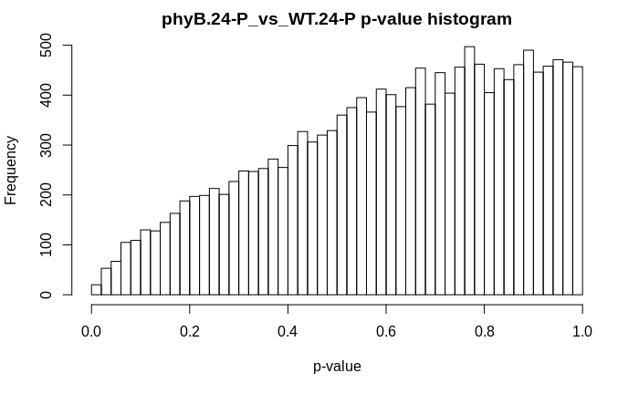

```r
# --- inputs --- #
folder <- "wound_control"
cont <- "phyB.24-P_vs_WT.24-P"
conds <- c("WT.P", "WT.24", "phyB.P", "phyB.24")
FDRmax <- 0.05
logFCmin <- 1
# ---        --- #
qlf <- glmQLFTest(LmFit, contrast=fullContrasts[, cont])
allGenes <- as.data.frame(topTags(qlf, n=Inf, p.value=1))
DEGs <- subset(allGenes, (FDR<FDRmax) & (abs(logFC)>logFCmin))
DEGs <- addAvgCpm(DEGs, woundDGEdata, groups=conds)
save_DEGs(DEGs, folder, cont, FDRmax, logFCmin, dirPath)
fig <- hist(allGenes$PValue, breaks=40, main=paste(cont, "p-value histogram", sep=" "),
         xlab = "p-value")
figFile <- makeFname(folder=paste(folder, "/plots", sep=""), cont=cont,
                     dtype="_p_val_hist", FDRmax=FDRmax, logFCmin=logFCmin)
figFile <- file.path(dirPath, figFile)
dev.copy(png, figFile)
```

```r
dev.off
```

[output not shown]

NOTE: even the exact test is influenced by the dispersion calculation and thus by the S condition.

To avoid our wound control gene lists being impacted by the S condition and the linear model, we will use direct comparisons with fischer exact tests to generate wound control genes.

### WT.24 vs WT.P

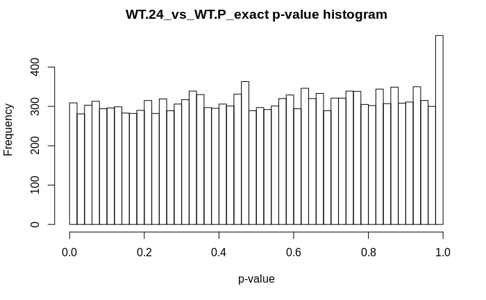

### phyB.24 - phyB.P

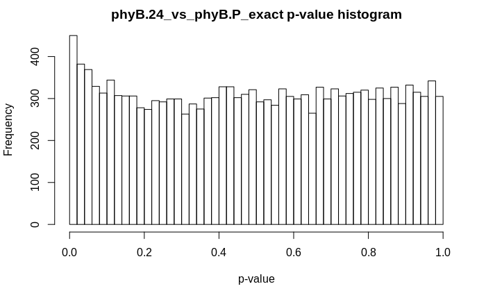

### collection of all wound controll genes

```r
# --- inputs --- #
folder <- "wound_control"
cont <- "wound_ctrl_genes"
FDRmax <- 0.05
logFCmin <- 1
# --- ------ --- #
woundIDs <- unique(c(row.names(woundDEGsWT), row.names(woundDEGsphyB)))
fname <- makeFname(folder=folder, cont=cont, FDRmax=FDRmax, logFCmin=logFCmin)
fPath <- file.path(dirPath, fname)
write.table(woundIDs, fPath, row.names=FALSE, na="", col.names=FALSE, sep=",")
```

# Timepoint v. Timepoint

## S vs P

### WT S vs P

```r
# --- inputs --- #
folder <- "timepoint_v_timepoint"
cont <- "WT.S_vs_WT.P"
conds <- c("WT.P", "WT.S")
FDRmax <- 0.01
logFCmin <- 1
# --- ------ --- #
qlf <- glmQLFTest(LmFit, contrast=fullContrasts[, cont])
allGenes <- as.data.frame(topTags(qlf, n=Inf, p.value=1))
DEGs <- subset(allGenes, (FDR<FDRmax) & (abs(logFC)>logFCmin))
DEGs <- addWoundCtrl(DEGs, woundIDs)
DEGs <- addAvgCpm(DEGs, DGEdata, groups=conds)
save_DEGs(DEGs, folder, cont, FDRmax, logFCmin, dirPath)
hist(allGenes$PValue, breaks=40, main=paste(cont, "p-value histogram", sep=" "),
         xlab = "p-value")
figFile <- makeFname(folder=paste(folder, "/plots", sep=""), cont=cont,
                     dtype="_p_val_hist", FDRmax=FDRmax, logFCmin=logFCmin)
figFile <- file.path(dirPath, figFile)
dev.copy(png, figFile)
```

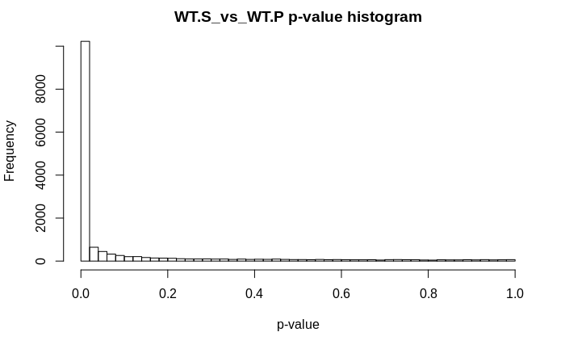

```r
dev.off()
```

```r
# -- specific --- #
allGenesWT_SvP <- allGenes
DEGsWT_SvP <- DEGs
head(DEGs, 20)
```

|  | logFC | logCPM | F | PValue | FDR | woundCtrl | WT.P_Avg_CPM | WT.S_Avg_CPM |
| --- | --- | --- | --- | --- | --- | --- | --- | --- |
| BraA06003490 | -4.003707 | 5.421752 | 532.3804 | 1.620138e-17 | 1.666165e-13 | FALSE | 46.287704 | 2.881876 |
| BraA04002129 | -10.368174 | 5.280835 | 504.0466 | 2.978767e-17 | 1.666165e-13 | FALSE | 48.80012229 | 0.02185446 |
| BraA06004345 | -2.754733 | 6.004471 | 501.1540 | 3.175665e-17 | 1.666165e-13 | FALSE | 79.24423 | 11.71657 |
| BraA08003307 | -3.437396 | 7.542639 | 399.4733 | 3.902428e-16 | 1.535605e-12 | FALSE | 221.32212 | 20.40327 |
| BraA06004803 | -2.720295 | 6.925501 | 378.5683 | 7.043288e-16 | 2.217227e-12 | FALSE | 164.50675 | 24.98322 |
| BraA06001576 | -3.387098 | 5.660343 | 363.1079 | 1.112200e-15 | 2.917672e-12 | FALSE | 63.472154 | 6.062191 |
| BraA03002180 | -2.506916 | 7.864701 | 346.2978 | 1.867044e-15 | 4.198182e-12 | FALSE | 287.60143 | 50.61252 |
| BraA09000087 | -7.480580 | 9.391923 | 336.5914 | 2.545538e-15 | 4.865169e-12 | FALSE | 1232.875507 | 6.977040 |
| BraA05000981 | -3.445458 | 5.837196 | 330.2877 | 3.127336e-15 | 4.865169e-12 | FALSE | 75.479617 | 6.941953 |
| BraA01000537 | -5.140202 | 11.668770 | 329.7574 | 3.182495e-15 | 4.865169e-12 | FALSE | 4164.8203 | 118.2021 |

[output cut: 10 more lines]

### phyB S vs P

```r
# --- inputs --- #
folder <- "timepoint_v_timepoint"
cont <- "phyB.S_vs_phyB.P"
conds <- c("phyB.P", "phyB.S")
FDRmax <- 0.01
logFCmin <- 1
# --- ------ --- #
qlf <- glmQLFTest(LmFit, contrast=fullContrasts[, cont])
allGenes <- as.data.frame(topTags(qlf, n=Inf, p.value=1))
DEGs <- subset(allGenes, (FDR<FDRmax) & (abs(logFC)>logFCmin))
DEGs <- addWoundCtrl(DEGs, woundIDs)
DEGs <- addAvgCpm(DEGs, DGEdata, groups=conds)
save_DEGs(DEGs, folder, cont, FDRmax, logFCmin, dirPath)
hist(allGenes$PValue, breaks=40, main=paste(cont, "p-value histogram", sep=" "),
         xlab = "p-value")
figFile <- makeFname(folder=paste(folder, "/plots", sep=""), cont=cont,
                     dtype="_p_val_hist", FDRmax=FDRmax, logFCmin=logFCmin)
figFile <- file.path(dirPath, figFile)
dev.copy(png, figFile)
```

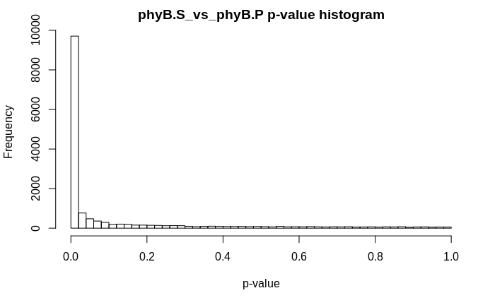

```r
dev.off()
```

```r
# -- specific --- #
allGenesphyB_SvP <- allGenes
DEGsphyB_SvP <- DEGs
head(DEGs, 20)
```

|  | logFC | logCPM | F | PValue | FDR | woundCtrl | phyB.P_Avg_CPM | phyB.S_Avg_CPM |
| --- | --- | --- | --- | --- | --- | --- | --- | --- |
| BraA04002129 | -9.700901 | 5.280835 | 401.9877 | 3.642098e-16 | 5.732663e-12 | FALSE | 63.37599876 | 0.06887702 |
| BraA06003490 | -3.690017 | 5.421752 | 359.3119 | 1.247714e-15 | 9.819507e-12 | FALSE | 49.889306 | 3.873098 |
| BraA06004345 | -2.482648 | 6.004471 | 315.5692 | 5.132009e-15 | 2.692594e-11 | FALSE | 83.94639 | 15.01523 |
| BraA05004133 | -6.867355 | 5.302192 | 270.3425 | 2.724488e-14 | 1.072086e-10 | FALSE | 59.826018 | 0.477744 |
| BraA10002909 | -5.716441 | 7.845652 | 263.3022 | 3.615289e-14 | 1.138093e-10 | FALSE | 270.041713 | 5.128057 |
| BraA01003391 | 2.746958 | 9.271276 | 258.2160 | 4.454511e-14 | 1.168567e-10 | FALSE | 283.8053 | 1905.2715 |
| BraA08003464 | -6.550220 | 7.988040 | 246.0660 | 7.450762e-14 | 1.529554e-10 | FALSE | 333.898631 | 3.533537 |
| BraA10003025 | -2.722747 | 5.596262 | 242.5344 | 8.690353e-14 | 1.529554e-10 | FALSE | 57.468244 | 8.678963 |
| BraA06002244 | -3.036041 | 6.534667 | 242.3893 | 8.745860e-14 | 1.529554e-10 | FALSE | 118.50140 | 14.44500 |
| BraA09000087 | -7.125180 | 9.391923 | 236.4444 | 1.138709e-13 | 1.792328e-10 | FALSE | 852.561423 | 6.072929 |

[output cut: 10 more lines]

### phyB S-P vs WT S-P

```r
# --- inputs --- #
folder <- "geno_x_timepoint"
cont <- "phyB.S-P_vs_WT.S-P"
conds <- c("WT.P", "phyB.P", "WT.S", "phyB.S")
FDRmax <- 0.1
logFCmin <- 0
# --- ------ --- #
qlf <- glmQLFTest(LmFit, contrast=fullContrasts[, cont])
allGenes <- as.data.frame(topTags(qlf, n=Inf, p.value=1))
DEGs <- subset(allGenes, (FDR<FDRmax) & (abs(logFC)>logFCmin))
DEGs <- addWoundCtrl(DEGs, woundIDs)
DEGs <- addAvgCpm(DEGs, DGEdata, groups=conds)
save_DEGs(DEGs, folder, cont, FDRmax, logFCmin, dirPath)
hist(allGenes$PValue, breaks=40, main=paste(cont, "p-value histogram", sep=" "),
         xlab = "p-value")
figFile <- makeFname(folder=paste(folder, "/plots", sep=""), cont=cont,
                     dtype="_p_val_hist", FDRmax=FDRmax, logFCmin=logFCmin)
figFile <- file.path(dirPath, figFile)
dev.copy(png, figFile)
```

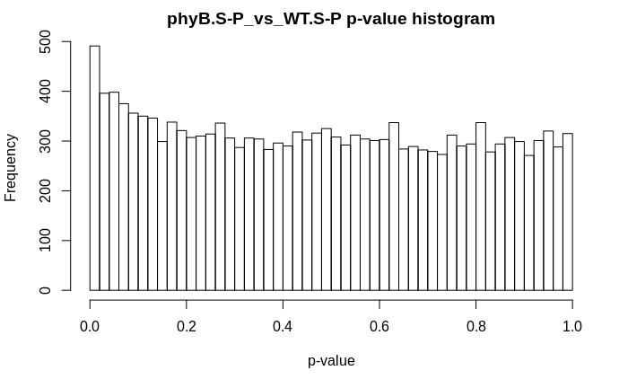

```r
dev.off()
```

```r
# --- specific --- #
DEGs_SvP <- DEGs
```

### Venn diagram of S vs. P

```r
# --- inputs --- #
folder <- "timepoint_v_timepoint/SvP_venn"
cont <- "SvP"
conds <- c("WT.P", "phyB.P", "WT.S", "phyB.S")
FDRmax <- 0.01
logFCmin <- 1
# --- ------ --- #
allGenes_SvP <- mergeGenes(allGenesWT_SvP, allGenesphyB_SvP)
allGenes_SvP <- addAvgCpm(allGenes_SvP, DGEdata, groups=conds)
colnames(allGenes_SvP) <- gsub("\\.x", "_WT", colnames(allGenes_SvP))
colnames(allGenes_SvP) <- gsub("\\.y", "_phyB", colnames(allGenes_SvP))
allGenes_SvP <- dplyr::left_join(allGenes_SvP, edinburghGeneInfo, by="Gene_ID")
row.names(allGenes_SvP) <- allGenes_SvP$Gene_ID
fname <- makeFname(folder=folder, cont="SvP_all_genes", FDRmax=FDRmax, logFCmin=logFCmin)
fPath <- file.path(dirPath, fname)
write.csv(allGenes_SvP, fPath, row.names=TRUE)
# --- UP --- #
group <- plyr::aaply(.data=allGenes_SvP, .margins=1, .fun=setGroup, change="up",
                       sigLvl=FDRmax, LFCutoff=logFCmin, .expand=FALSE)
allGenes_SvP$group <- group
save_Venn_Lists(allGenesList=allGenes_SvP,
                folder=folder,
                cont=cont,
                FDRmax=FDRmax,
                logFCmin=logFCmin,
                change="_UP",
                dir=dirPath)
sum(allGenes_SvP$group %in% c("WT_sig", "Both_sig"))
```

```
[1] 3534
```

```r
plot.new()
temp <- draw.pairwise.venn(area1=sum(allGenes_SvP$group %in% c("WT_sig", "Both_sig")),
                           area2=sum(allGenes_SvP$group %in% c("phyB_sig", "Both_sig")),
                           cross.area=sum(allGenes_SvP$group %in% c("Both_sig")),
                   fill=c("blue", "red"), category=c("WT S vs. P", "phyB S vs. P"))
```

```r
grid.draw(temp)
figFile <- makeFname(folder=folder, cont=paste(cont, "_UP", sep=""), dtype="_Venn_diag", FDRmax=FDRmax, logFCmin=logFCmin)
figFile <- file.path(dirPath, figFile)
dev.copy(png, figFile)
```

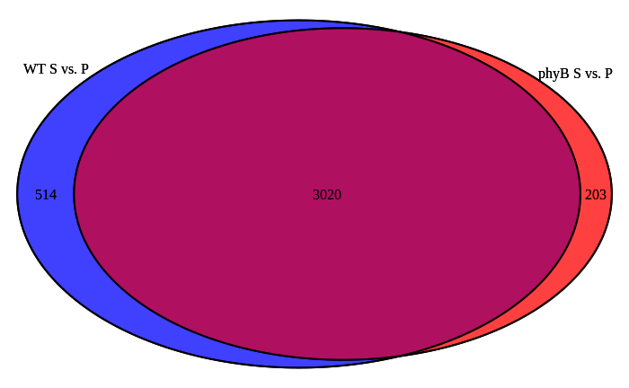

```r
dev.off()
```

```r
cols <- c("none"="grey50", "phyB_sig"="red", "WT_sig"="blue", "Both_sig"="purple")
plotData <- allGenes_SvP
ggplot(plotData, aes(x=logFC_WT, y=logFC_phyB, color=group)) +
  geom_point(data=subset(plotData, group=="none"), alpha=0.2, stroke=0) +
  geom_point(data=subset(plotData, group=="Both_sig"), alpha=0.5, stroke=0) +
  geom_point(data=subset(plotData, group=="phyB_sig"), alpha=0.5, stroke=0) +
  geom_point(data=subset(plotData, group=="WT_sig"), alpha=0.5, stroke=0) +
  scale_color_manual(values=cols) +
  labs(x = "WT logFC", y="phyB logFC", title="logFC S vs. P")
figFile <- makeFname(folder=folder, cont=paste(cont, "_UP", sep=""), dtype="_LogFC_plot", FDRmax=FDRmax, logFCmin=logFCmin)
figFile <- file.path(dirPath, figFile)
dev.copy(png, figFile)
```

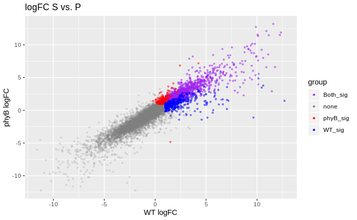

```r
dev.off()
```

```r
# --- DOWN --- #
group <- plyr::aaply(.data=allGenes_SvP, .margins=1, .fun=setGroup, change="down",
                       sigLvl=FDRmax, LFCutoff=logFCmin, .expand=FALSE)
allGenes_SvP$group <- group
save_Venn_Lists(allGenesList=allGenes_SvP,
                folder=folder,
                cont=cont,
                FDRmax=FDRmax,
                logFCmin=logFCmin,
                change="_DOWN",
                dir=dirPath)
sum(allGenes_SvP$group %in% c("WT_sig", "Both_sig"))
```

```
[1] 3904
```

```r
plot.new()
temp <- draw.pairwise.venn(area1=sum(allGenes_SvP$group %in% c("WT_sig", "Both_sig")),
                           area2=sum(allGenes_SvP$group %in% c("phyB_sig", "Both_sig")),
                           cross.area=sum(allGenes_SvP$group %in% c("Both_sig")),
                   fill=c("blue", "red"), category=c("WT S vs. P", "phyB S vs. P"))
```

```r
grid.draw(temp)
figFile <- makeFname(folder=folder, cont=paste(cont, "_DOWN", sep=""), dtype="_Venn_diag", FDRmax=FDRmax, logFCmin=logFCmin)
figFile <- file.path(dirPath, figFile)
dev.copy(png, figFile)
```

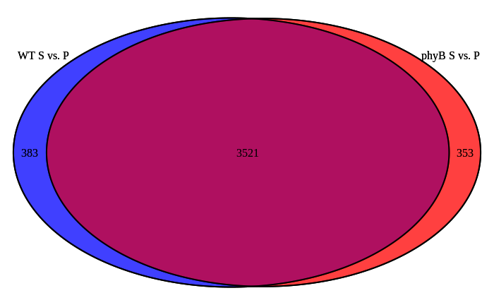

```r
dev.off()
```

```r
cols <- c("none"="grey50", "phyB_sig"="red", "WT_sig"="blue", "Both_sig"="purple")
plotData <- allGenes_SvP
ggplot(plotData, aes(x=logFC_WT, y=logFC_phyB, color=group)) +
  geom_point(data=subset(plotData, group=="none"), alpha=0.2, stroke=0) +
  geom_point(data=subset(plotData, group=="Both_sig"), alpha=0.5, stroke=0) +
  geom_point(data=subset(plotData, group=="phyB_sig"), alpha=0.5, stroke=0) +
  geom_point(data=subset(plotData, group=="WT_sig"), alpha=0.5, stroke=0) +
  scale_color_manual(values=cols) +
  labs(x = "WT logFC", y="phyB logFC", title="logFC S vs. P")
figFile <- makeFname(folder=folder, cont=paste(cont, "_DOWN", sep=""), dtype="_LogFC_plot", FDRmax=FDRmax, logFCmin=logFCmin)
figFile <- file.path(dirPath, figFile)
dev.copy(png, figFile)
```

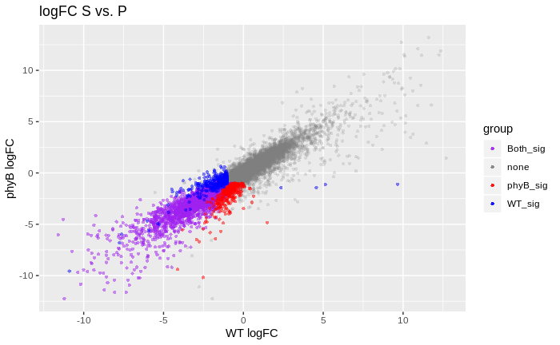

```r
dev.off()
```

## R vs. S

### WT R vs. S

```r
# --- inputs --- #
folder <- "timepoint_v_timepoint"
cont <- "WT.R_vs_WT.S"
conds <- c("WT.S", "WT.R")
FDRmax <- 0.01
logFCmin <- 1
# --- ------ --- #
qlf <- glmQLFTest(LmFit, contrast=fullContrasts[, cont])
allGenes <- as.data.frame(topTags(qlf, n=Inf, p.value=1))
DEGs <- subset(allGenes, (FDR<FDRmax) & (abs(logFC)>logFCmin))
DEGs <- addWoundCtrl(DEGs, woundIDs)
DEGs <- addAvgCpm(DEGs, DGEdata, groups=conds)
save_DEGs(DEGs, folder, cont, FDRmax, logFCmin, dirPath)
hist(allGenes$PValue, breaks=40, main=paste(cont, "p-value histogram", sep=" "),
         xlab = "p-value")
figFile <- makeFname(folder=paste(folder, "/plots", sep=""), cont=cont,
                     dtype="_p_val_hist", FDRmax=FDRmax, logFCmin=logFCmin)
figFile <- file.path(dirPath, figFile)
dev.copy(png, figFile)
```

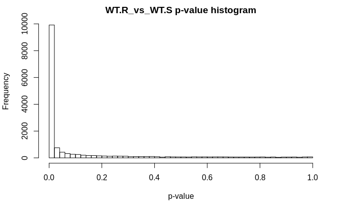

```r
dev.off()
```

```r
# -- specific --- #
allGenesWT_RvS <- allGenes
DEGsWT_RvS <- DEGs
head(DEGs, 20)
```

|  | logFC | logCPM | F | PValue | FDR | woundCtrl | WT.S_Avg_CPM | WT.R_Avg_CPM |
| --- | --- | --- | --- | --- | --- | --- | --- | --- |
| BraA06003490 | 4.757538 | 5.421752 | 714.9014 | 5.951452e-19 | 9.367585e-15 | FALSE | 2.881876 | 78.041506 |
| BraA06004345 | 2.808515 | 6.004471 | 519.9086 | 2.109918e-17 | 1.359794e-13 | FALSE | 11.71657 | 82.25854 |
| BraA08003307 | 3.977805 | 7.542639 | 510.3918 | 2.591729e-17 | 1.359794e-13 | FALSE | 20.40327 | 321.84615 |
| BraA04002129 | 10.121496 | 5.280835 | 478.9477 | 5.254125e-17 | 2.067498e-13 | FALSE | 0.02185446 | 41.17649542 |
| BraA06001576 | 3.655588 | 5.660343 | 415.5920 | 2.524321e-16 | 7.946562e-13 | FALSE | 6.062191 | 76.419014 |
| BraA07003370 | 3.842372 | 6.942362 | 400.1322 | 3.832304e-16 | 9.980180e-13 | FALSE | 13.64576 | 195.19708 |
| BraA05003669 | 5.068873 | 9.017201 | 394.8256 | 4.438453e-16 | 9.980180e-13 | FALSE | 25.64127 | 858.01613 |
| BraA06002244 | 3.339488 | 6.534667 | 379.9209 | 6.773019e-16 | 1.332592e-12 | FALSE | 13.72675 | 138.99035 |
| BraA05000981 | 3.697863 | 5.837196 | 373.9052 | 8.068645e-16 | 1.411116e-12 | FALSE | 6.941953 | 89.872055 |
| BraA05004133 | 7.240043 | 5.302192 | 368.1790 | 9.555194e-16 | 1.503988e-12 | FALSE | 0.417879 | 59.609409 |

[output cut: 10 more lines]

### phyB R vs. S

```r
# --- inputs --- #
folder <- "timepoint_v_timepoint"
cont <- "phyB.R_vs_phyB.S"
conds <- c("phyB.S", "phyB.R")
FDRmax <- 0.01
logFCmin <- 1
# --- ------ --- #
qlf <- glmQLFTest(LmFit, contrast=fullContrasts[, cont])
allGenes <- as.data.frame(topTags(qlf, n=Inf, p.value=1))
DEGs <- subset(allGenes, (FDR<FDRmax) & (abs(logFC)>logFCmin))
DEGs <- addWoundCtrl(DEGs, woundIDs)
DEGs <- addAvgCpm(DEGs, DGEdata, groups=conds)
save_DEGs(DEGs, folder, cont, FDRmax, logFCmin, dirPath)
hist(allGenes$PValue, breaks=40, main=paste(cont, "p-value histogram", sep=" "),
         xlab = "p-value")
figFile <- makeFname(folder=paste(folder, "/plots", sep=""), cont=cont,
                     dtype="_p_val_hist", FDRmax=FDRmax, logFCmin=logFCmin)
figFile <- file.path(dirPath, figFile)
dev.copy(png, figFile)
```

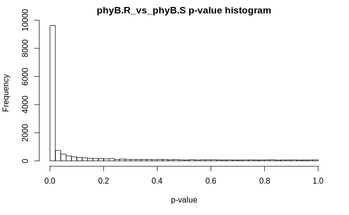

```r
dev.off()
```

```r
# -- specific --- #
allGenesphyB_RvS <- allGenes
DEGsphyB_RvS <- DEGs
head(DEGs, 20)
```

|  | logFC | logCPM | F | PValue | FDR | woundCtrl | phyB.S_Avg_CPM | phyB.R_Avg_CPM |
| --- | --- | --- | --- | --- | --- | --- | --- | --- |
| BraA06003490 | 4.163701 | 5.421752 | 441.9767 | 1.279384e-16 | 2.013751e-12 | FALSE | 3.873098 | 69.264532 |
| BraA10002909 | 6.445113 | 7.845652 | 314.1910 | 5.381544e-15 | 4.235276e-11 | FALSE | 5.128057 | 447.450942 |
| BraA10003025 | 3.071155 | 5.596262 | 301.0563 | 8.546275e-15 | 4.394349e-11 | FALSE | 8.678963 | 73.173729 |
| BraA04002129 | 8.304840 | 5.280835 | 293.6952 | 1.116734e-14 | 4.394349e-11 | FALSE | 0.06887702 | 24.08267647 |
| BraA08003307 | 3.254049 | 7.542639 | 274.7365 | 2.291376e-14 | 5.719233e-11 | FALSE | 29.38899 | 280.43294 |
| BraA06001576 | 3.358788 | 5.660343 | 273.0544 | 2.447638e-14 | 5.719233e-11 | FALSE | 7.061591 | 72.634809 |
| BraA04001528 | 4.785199 | 5.485841 | 269.8901 | 2.773895e-14 | 5.719233e-11 | FALSE | 2.705607 | 75.507952 |
| BraA05004133 | 6.842423 | 5.302192 | 268.7149 | 2.906853e-14 | 5.719233e-11 | FALSE | 0.477744 | 58.769162 |
| BraA06004345 | 2.240551 | 6.004471 | 261.0976 | 3.955835e-14 | 6.918317e-11 | FALSE | 15.01523 | 70.97231 |
| BraA08003464 | 6.744885 | 7.988040 | 256.6841 | 4.747102e-14 | 6.948679e-11 | FALSE | 3.533537 | 382.160624 |

[output cut: 10 more lines]

### phyB R-S vs WT R-S

```r
# --- inputs --- #
folder <- "geno_x_timepoint"
cont <- "phyB.R-S_vs_WT.R-S"
conds <- c("WT.S", "phyB.S", "WT.R", "phyB.R")
FDRmax <- 0.1
logFCmin <- 0
# --- ------ --- #
qlf <- glmQLFTest(LmFit, contrast=fullContrasts[, cont])
allGenes <- as.data.frame(topTags(qlf, n=Inf, p.value=1))
DEGs <- subset(allGenes, (FDR<FDRmax) & (abs(logFC)>logFCmin))
DEGs <- addWoundCtrl(DEGs, woundIDs)
DEGs <- addAvgCpm(DEGs, DGEdata, groups=conds)
save_DEGs(DEGs, folder, cont, FDRmax, logFCmin, dirPath)
hist(allGenes$PValue, breaks=40, main=paste(cont, "p-value histogram", sep=" "),
         xlab = "p-value")
figFile <- makeFname(folder=paste(folder, "/plots", sep=""), cont=cont,
                     dtype="_p_val_hist", FDRmax=FDRmax, logFCmin=logFCmin)
figFile <- file.path(dirPath, figFile)
dev.copy(png, figFile)
```

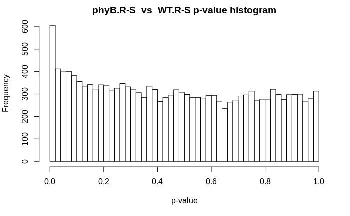

```r
dev.off()
```

```r
# --- specific --- #
DEGs_RvS <- DEGs
```

### venn diagarm R vs. S

```r
# --- inputs --- #
folder <- "timepoint_v_timepoint/RvS_venn"
cont <- "RvS"
conds <- c("WT.S", "phyB.S", "WT.R", "phyB.R")
FDRmax <- 0.01
logFCmin <- 1
# --- ------ --- #
allGenes_RvS <- mergeGenes(allGenesWT_RvS, allGenesphyB_RvS)
allGenes_RvS <- addAvgCpm(allGenes_RvS, DGEdata, groups=conds)
colnames(allGenes_RvS) <- gsub("\\.x", "_WT", colnames(allGenes_RvS))
colnames(allGenes_RvS) <- gsub("\\.y", "_phyB", colnames(allGenes_RvS))
allGenes_RvS <- dplyr::left_join(allGenes_RvS, edinburghGeneInfo, by="Gene_ID")
row.names(allGenes_RvS) <- allGenes_RvS$Gene_ID
fname <- makeFname(folder=folder, cont="RvS_all_genes", FDRmax=FDRmax, logFCmin=logFCmin)
fPath <- file.path(dirPath, fname)
write.csv(allGenes_RvS, fPath, row.names=TRUE)
# --- UP --- #
group <- plyr::aaply(.data=allGenes_RvS, .margins=1, .fun=setGroup, change="up",
                       sigLvl=FDRmax, LFCutoff=logFCmin, .expand=FALSE)
allGenes_RvS$group <- group
save_Venn_Lists(allGenesList=allGenes_RvS,
                folder=folder,
                cont=cont,
                FDRmax=FDRmax,
                logFCmin=logFCmin,
                change="_UP",
                dir=dirPath)
sum(allGenes_RvS$group %in% c("WT_sig", "Both_sig"))
```

```
[1] 3756
```

```r
plot.new()
temp <- draw.pairwise.venn(area1=sum(allGenes_RvS$group %in% c("WT_sig", "Both_sig")),
                           area2=sum(allGenes_RvS$group %in% c("phyB_sig", "Both_sig")),
                           cross.area=sum(allGenes_RvS$group %in% c("Both_sig")),
                   fill=c("blue", "red"), category=c("WT R vs. S", "phyB R vs. S"))
```

```r
grid.draw(temp)
figFile <- makeFname(folder=folder, cont=paste(cont, "_UP", sep=""), dtype="_Venn_diag", FDRmax=FDRmax, logFCmin=logFCmin)
figFile <- file.path(dirPath, figFile)
dev.copy(png, figFile)
```

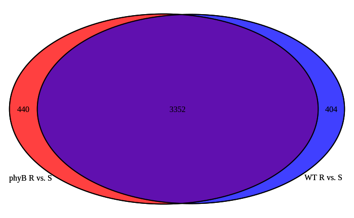

```r
dev.off()
```

```r
cols <- c("none"="grey50", "phyB_sig"="red", "WT_sig"="blue", "Both_sig"="purple")
plotData <- allGenes_RvS
ggplot(plotData, aes(x=logFC_WT, y=logFC_phyB, color=group)) +
  geom_point(data=subset(plotData, group=="none"), alpha=0.2, stroke=0) +
  geom_point(data=subset(plotData, group=="Both_sig"), alpha=0.5, stroke=0) +
  geom_point(data=subset(plotData, group=="phyB_sig"), alpha=0.5, stroke=0) +
  geom_point(data=subset(plotData, group=="WT_sig"), alpha=0.5, stroke=0) +
  scale_color_manual(values=cols) +
  labs(x = "WT logFC", y="phyB logFC", title="logFC R vs. S")
figFile <- makeFname(folder=folder, cont=paste(cont, "_UP", sep=""), dtype="_LogFC_plot", FDRmax=FDRmax, logFCmin=logFCmin)
figFile <- file.path(dirPath, figFile)
dev.copy(png, figFile)
```

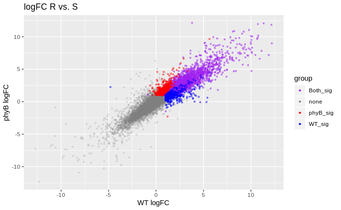

```r
dev.off()
```

```r
# --- DOWN --- #
group <- plyr::aaply(.data=allGenes_RvS, .margins=1, .fun=setGroup, change="down",
                       sigLvl=FDRmax, LFCutoff=logFCmin, .expand=FALSE)
allGenes_RvS$group <- group
save_Venn_Lists(allGenesList=allGenes_RvS,
                folder=folder,
                cont=cont,
                FDRmax=FDRmax,
                logFCmin=logFCmin,
                change="_DOWN",
                dir=dirPath)
sum(allGenes_RvS$group %in% c("WT_sig", "Both_sig"))
```

```
[1] 3299
```

```r
plot.new()
temp <- draw.pairwise.venn(area1=sum(allGenes_RvS$group %in% c("WT_sig", "Both_sig")),
                           area2=sum(allGenes_RvS$group %in% c("phyB_sig", "Both_sig")),
                           cross.area=sum(allGenes_RvS$group %in% c("Both_sig")),
                   fill=c("blue", "red"), category=c("WT R vs. S", "phyB R vs. S"))
```

```r
grid.draw(temp)
figFile <- makeFname(folder=folder, cont=paste(cont, "_DOWN", sep=""), dtype="_Venn_diag", FDRmax=FDRmax, logFCmin=logFCmin)
figFile <- file.path(dirPath, figFile)
dev.copy(png, figFile)
```

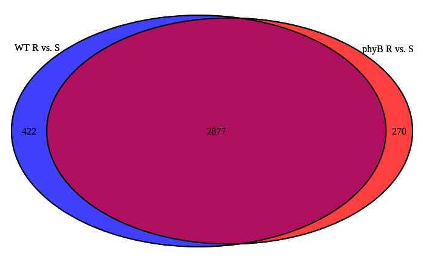

```r
dev.off()
```

```r
cols <- c("none"="grey50", "phyB_sig"="red", "WT_sig"="blue", "Both_sig"="purple")
plotData <- allGenes_RvS
ggplot(plotData, aes(x=logFC_WT, y=logFC_phyB, color=group)) +
  geom_point(data=subset(plotData, group=="none"), alpha=0.2, stroke=0) +
  geom_point(data=subset(plotData, group=="Both_sig"), alpha=0.5, stroke=0) +
  geom_point(data=subset(plotData, group=="phyB_sig"), alpha=0.5, stroke=0) +
  geom_point(data=subset(plotData, group=="WT_sig"), alpha=0.5, stroke=0) +
  scale_color_manual(values=cols) +
  labs(x = "WT logFC", y="phyB logFC", title="logFC R vs. S")
figFile <- makeFname(folder=folder, cont=paste(cont, "_DOWN", sep=""), dtype="_LogFC_plot", FDRmax=FDRmax, logFCmin=logFCmin)
figFile <- file.path(dirPath, figFile)
dev.copy(png, figFile)
```

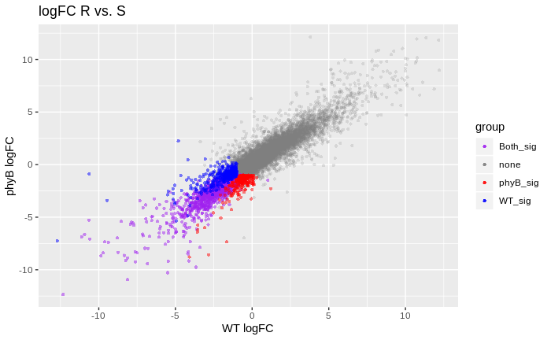

```r
dev.off()
```

## R vs. P

### WT R vs. P

```r
# --- inputs --- #
folder <- "timepoint_v_timepoint"
cont <- "WT.R_vs_WT.P"
conds <- c("WT.P", "WT.R")
FDRmax <- 0.01
logFCmin <- 1
# --- ------ --- #
qlf <- glmQLFTest(LmFit, contrast=fullContrasts[, cont])
allGenes <- as.data.frame(topTags(qlf, n=Inf, p.value=1))
DEGs <- subset(allGenes, (FDR<FDRmax) & (abs(logFC)>logFCmin))
DEGs <- addWoundCtrl(DEGs, woundIDs)
DEGs <- addAvgCpm(DEGs, DGEdata, groups=conds)
save_DEGs(DEGs, folder, cont, FDRmax, logFCmin, dirPath)
hist(allGenes$PValue, breaks=40, main=paste(cont, "p-value histogram", sep=" "),
         xlab = "p-value")
figFile <- makeFname(folder=paste(folder, "/plots", sep=""), cont=cont,
                     dtype="_p_val_hist", FDRmax=FDRmax, logFCmin=logFCmin)
figFile <- file.path(dirPath, figFile)
dev.copy(png, figFile)
```

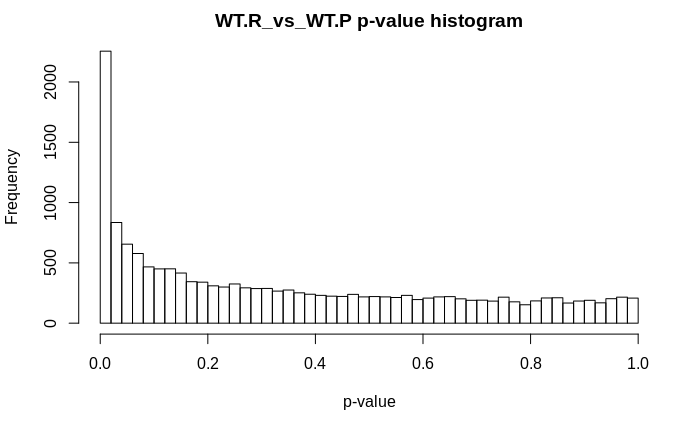

```r
dev.off()
```

```r
# -- specific --- #
allGenesWT_RvP <- allGenes
DEGsWT_RvP <- DEGs
head(DEGs, 20)
```

|  | logFC | logCPM | F | PValue | FDR | woundCtrl | WT.P_Avg_CPM | WT.R_Avg_CPM |
| --- | --- | --- | --- | --- | --- | --- | --- | --- |
| BraA02003663 | 1.343492 | 4.304304 | 61.55770 | 5.581145e-08 | 0.0003466769 | FALSE | 16.007842 | 40.546687 |
| BraA09002291 | -2.742044 | 3.959521 | 60.72826 | 6.266698e-08 | 0.0003466769 | FALSE | 27.048295 | 4.008762 |
| BraA05003570 | 1.633275 | 5.025324 | 58.45208 | 8.664921e-08 | 0.0003466769 | FALSE | 14.18459 | 43.92674 |
| BraA02001561 | 1.311395 | 3.931741 | 56.31864 | 1.183989e-07 | 0.0003466769 | FALSE | 9.738757 | 24.174299 |
| BraA01001602 | 2.123221 | 4.514142 | 56.21732 | 1.201928e-07 | 0.0003466769 | FALSE | 10.42357 | 45.85781 |
| BraA05004010 | 2.644072 | 3.404683 | 55.58130 | 1.321513e-07 | 0.0003466769 | FALSE | 4.202938 | 26.906966 |
| BraA01000203 | 7.207108 | 2.819976 | 54.36773 | 1.587165e-07 | 0.0003473878 | FALSE | 0.05220689 | 10.84552914 |
| BraA01004327 | -1.830721 | 6.020116 | 53.67055 | 1.765631e-07 | 0.0003473878 | FALSE | 81.87949 | 22.99861 |
| BraA06001158 | 1.176310 | 7.386417 | 50.24733 | 3.023731e-07 | 0.0005288169 | FALSE | 125.84426 | 284.61305 |
| BraA06004547 | 2.810024 | 5.545539 | 49.29509 | 3.527933e-07 | 0.0005552967 | FALSE | 15.401565 | 109.401724 |

[output cut: 10 more lines]

### phyB R vs. P

```r
# --- inputs --- #
folder <- "timepoint_v_timepoint"
cont <- "phyB.R_vs_phyB.P"
conds <- c("phyB.P", "phyB.R")
FDRmax <- 0.01
logFCmin <- 1
# --- ------ --- #
qlf <- glmQLFTest(LmFit, contrast=fullContrasts[, cont])
allGenes <- as.data.frame(topTags(qlf, n=Inf, p.value=1))
DEGs <- subset(allGenes, (FDR<FDRmax) & (abs(logFC)>logFCmin))
DEGs <- addWoundCtrl(DEGs, woundIDs)
DEGs <- addAvgCpm(DEGs, DGEdata, groups=conds)
save_DEGs(DEGs, folder, cont, FDRmax, logFCmin, dirPath)
hist(allGenes$PValue, breaks=40, main=paste(cont, "p-value histogram", sep=" "),
         xlab = "p-value")
figFile <- makeFname(folder=paste(folder, "/plots", sep=""), cont=cont,
                     dtype="_p_val_hist", FDRmax=FDRmax, logFCmin=logFCmin)
figFile <- file.path(dirPath, figFile)
dev.copy(png, figFile)
```

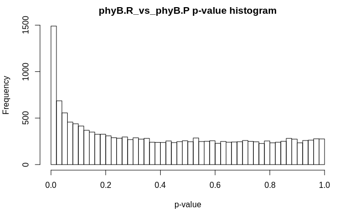

```r
dev.off()
```

```r
# -- specific --- #
allGenesphyB_RvP <- allGenes
DEGsphyB_RvP <- DEGs
head(DEGs, 20)
```

|  | logFC | logCPM | F | PValue | FDR | woundCtrl | phyB.P_Avg_CPM | phyB.R_Avg_CPM |
| --- | --- | --- | --- | --- | --- | --- | --- | --- |
| BraA10002022 | 2.426189 | 4.849863 | 59.88833 | 7.055200e-08 | 0.0009146347 | FALSE | 15.26297 | 82.07354 |
| BraA01004053 | -4.283613 | 7.117877 | 55.36434 | 1.365216e-07 | 0.0009146347 | FALSE | 154.8246785 | 7.9325893 |
| BraA05003570 | 1.752681 | 5.025324 | 52.14794 | 2.236038e-07 | 0.0009146347 | FALSE | 29.06078 | 97.94362 |
| BraA02001561 | 1.436019 | 3.931741 | 51.90118 | 2.324358e-07 | 0.0009146347 | FALSE | 11.386771 | 30.837403 |
| BraA03004311 | 3.244961 | 3.490001 | 47.76261 | 4.541791e-07 | 0.0010956218 | FALSE | 4.8758232 | 46.2122686 |
| BraA08003182 | -2.485009 | 4.018128 | 47.46700 | 4.771651e-07 | 0.0010956218 | FALSE | 20.640640 | 3.681741 |
| BraA06000897 | -3.413765 | 7.910501 | 47.34212 | 4.872524e-07 | 0.0010956218 | FALSE | 319.38836 | 29.93563 |
| BraA09005650 | -3.290561 | 6.397082 | 46.24151 | 5.868804e-07 | 0.0011546871 | FALSE | 51.988157 | 5.334821 |
| BraA05004167 | -1.599998 | 5.132338 | 45.37347 | 6.810915e-07 | 0.0011911534 | FALSE | 45.798961 | 15.088302 |
| BraA05003648 | 2.070855 | 3.577642 | 43.73083 | 9.075973e-07 | 0.0014285582 | FALSE | 8.518326 | 35.776916 |

[output cut: 10 more lines]

### phyB R-P vs WT R-P

```r
# --- inputs --- #
folder <- "geno_x_timepoint"
cont <- "phyB.R-P_vs_WT.R-P"
conds <- c("WT.P", "phyB.P", "WT.R", "phyB.R")
FDRmax <- 0.1
logFCmin <- 0
# --- ------ --- #
qlf <- glmQLFTest(LmFit, contrast=fullContrasts[, cont])
allGenes <- as.data.frame(topTags(qlf, n=Inf, p.value=1))
DEGs <- subset(allGenes, (FDR<FDRmax) & (abs(logFC)>logFCmin))
DEGs <- addWoundCtrl(DEGs, woundIDs)
DEGs <- addAvgCpm(DEGs, DGEdata, groups=conds)
save_DEGs(DEGs, folder, cont, FDRmax, logFCmin, dirPath)
hist(allGenes$PValue, breaks=40, main=paste(cont, "p-value histogram", sep=" "),
         xlab = "p-value")
figFile <- makeFname(folder=paste(folder, "/plots", sep=""), cont=cont,
                     dtype="_p_val_hist", FDRmax=FDRmax, logFCmin=logFCmin)
figFile <- file.path(dirPath, figFile)
dev.copy(png, figFile)
```

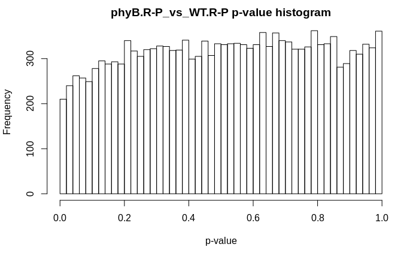

```r
dev.off()
```

```r
# --- specific --- #
DEGs_RvP <- DEGs
```

### venn diagarm R vs. P

```r
# --- inputs --- #
folder <- "timepoint_v_timepoint/RvP_venn"
cont <- "RvP"
conds <- c("WT.P", "phyB.P", "WT.R", "phyB.R")
FDRmax <- 0.01
logFCmin <- 1
# --- ------ --- #
allGenes_RvP <- mergeGenes(allGenesWT_RvP, allGenesphyB_RvP)
allGenes_RvP <- addAvgCpm(allGenes_RvP, DGEdata, groups=conds)
colnames(allGenes_RvP) <- gsub("\\.x", "_WT", colnames(allGenes_RvP))
colnames(allGenes_RvP) <- gsub("\\.y", "_phyB", colnames(allGenes_RvP))
allGenes_RvP <- dplyr::left_join(allGenes_RvP, edinburghGeneInfo, by="Gene_ID")
row.names(allGenes_RvP) <- allGenes_RvP$Gene_ID
fname <- makeFname(folder=folder, cont="RvP_all_genes", FDRmax=FDRmax, logFCmin=logFCmin)
fPath <- file.path(dirPath, fname)
write.csv(allGenes_RvP, fPath, row.names=TRUE)
# --- UP --- #
group <- plyr::aaply(.data=allGenes_RvP, .margins=1, .fun=setGroup, change="up",
                       sigLvl=FDRmax, LFCutoff=logFCmin, .expand=FALSE)
allGenes_RvP$group <- group
save_Venn_Lists(allGenesList=allGenes_RvP,
                folder=folder,
                cont=cont,
                FDRmax=FDRmax,
                logFCmin=logFCmin,
                change="_UP",
                dir=dirPath)
sum(allGenes_RvP$group %in% c("WT_sig", "Both_sig"))
```

```
[1] 100
```

```r
plot.new()
temp <- draw.pairwise.venn(area1=sum(allGenes_RvP$group %in% c("WT_sig", "Both_sig")),
                           area2=sum(allGenes_RvP$group %in% c("phyB_sig", "Both_sig")),
                           cross.area=sum(allGenes_RvP$group %in% c("Both_sig")),
                   fill=c("blue", "red"), category=c("WT R vs. P", "phyB R vs. P"))
```

```r
grid.draw(temp)
figFile <- makeFname(folder=folder, cont=paste(cont, "_UP", sep=""), dtype="_Venn_diag", FDRmax=FDRmax, logFCmin=logFCmin)
figFile <- file.path(dirPath, figFile)
dev.copy(png, figFile)
```

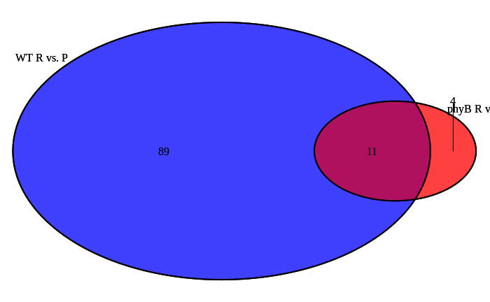

```r
dev.off()
```

```r
cols <- c("none"="grey50", "phyB_sig"="red", "WT_sig"="blue", "Both_sig"="purple")
plotData <- allGenes_RvP
ggplot(plotData, aes(x=logFC_WT, y=logFC_phyB, color=group)) +
  geom_point(data=subset(plotData, group=="none"), alpha=0.2, stroke=0) +
  geom_point(data=subset(plotData, group=="Both_sig"), alpha=0.5, stroke=0) +
  geom_point(data=subset(plotData, group=="phyB_sig"), alpha=0.5, stroke=0) +
  geom_point(data=subset(plotData, group=="WT_sig"), alpha=0.5, stroke=0) +
  scale_color_manual(values=cols) +
  labs(x = "WT logFC", y="phyB logFC", title="logFC R vs. P")
figFile <- makeFname(folder=folder, cont=paste(cont, "_UP", sep=""), dtype="_LogFC_plot", FDRmax=FDRmax, logFCmin=logFCmin)
figFile <- file.path(dirPath, figFile)
dev.copy(png, figFile)
```

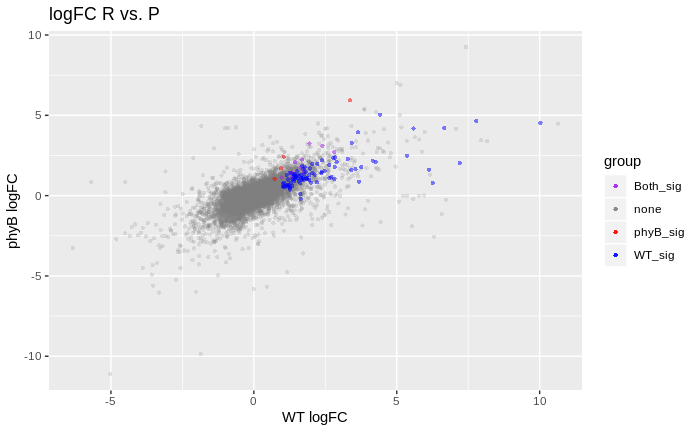

```r
dev.off()
```

```r
# --- DOWN --- #
group <- plyr::aaply(.data=allGenes_RvP, .margins=1, .fun=setGroup, change="down",
                       sigLvl=FDRmax, LFCutoff=logFCmin, .expand=FALSE)
allGenes_RvP$group <- group
save_Venn_Lists(allGenesList=allGenes_RvP,
                folder=folder,
                cont=cont,
                FDRmax=FDRmax,
                logFCmin=logFCmin,
                change="_DOWN",
                dir=dirPath)
sum(allGenes_RvP$group %in% c("WT_sig", "Both_sig"))
```

```
[1] 56
```

```r
plot.new()
temp <- draw.pairwise.venn(area1=sum(allGenes_RvP$group %in% c("WT_sig", "Both_sig")),
                           area2=sum(allGenes_RvP$group %in% c("phyB_sig", "Both_sig")),
                           cross.area=sum(allGenes_RvP$group %in% c("Both_sig")),
                   fill=c("blue", "red"), category=c("WT R vs. P", "phyB R vs. P"))
```

```r
grid.draw(temp)
figFile <- makeFname(folder=folder, cont=paste(cont, "_DOWN", sep=""), dtype="_Venn_diag", FDRmax=FDRmax, logFCmin=logFCmin)
figFile <- file.path(dirPath, figFile)
dev.copy(png, figFile)
```

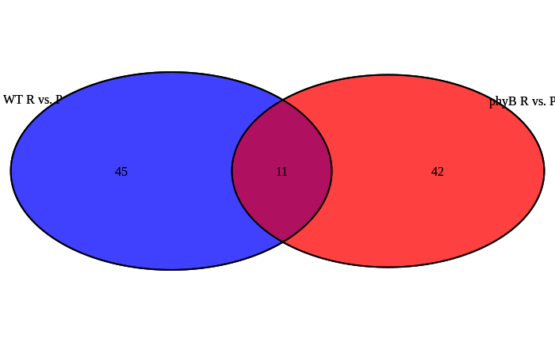

```r
dev.off()
```

```r
cols <- c("none"="grey50", "phyB_sig"="red", "WT_sig"="blue", "Both_sig"="purple")
plotData <- allGenes_RvP
ggplot(plotData, aes(x=logFC_WT, y=logFC_phyB, color=group)) +
  geom_point(data=subset(plotData, group=="none"), alpha=0.2, stroke=0) +
  geom_point(data=subset(plotData, group=="Both_sig"), alpha=0.5, stroke=0) +
  geom_point(data=subset(plotData, group=="phyB_sig"), alpha=0.5, stroke=0) +
  geom_point(data=subset(plotData, group=="WT_sig"), alpha=0.5, stroke=0) +
  scale_color_manual(values=cols) +
  labs(x = "WT logFC", y="phyB logFC", title="logFC R vs. P")
figFile <- makeFname(folder=folder, cont=paste(cont, "_DOWN", sep=""), dtype="_LogFC_plot", FDRmax=FDRmax, logFCmin=logFCmin)
figFile <- file.path(dirPath, figFile)
dev.copy(png, figFile)
```

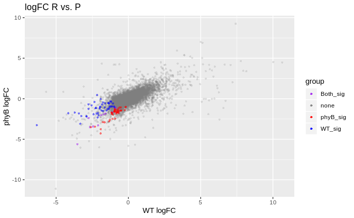

```r
dev.off()
```

## phyB vs WT at each timepoint (exact tests)

### phyB.P vs WT.P

Note: we’re using woundDGEdata here

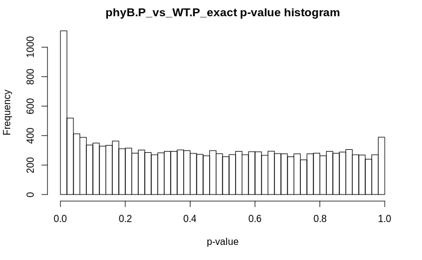

### phyB.24 vs WT.24

Note: we’re using woundDGEdata here

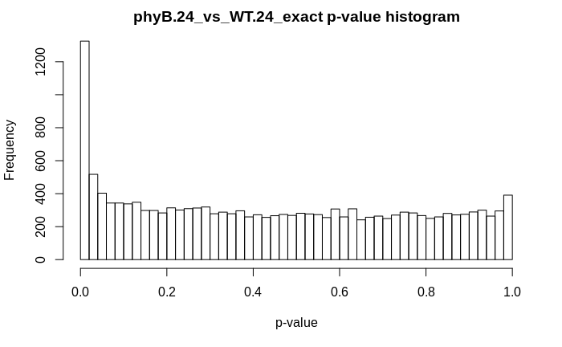

### phyB.S vs WT.S

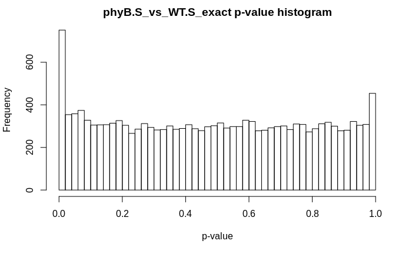

## GT at all time points at once

### phyB vs WT at P,S,R

```r
# --- inputs --- #
folder <- "phyB_v_WT_at_timepoint"
cont <- "phyB.PSR_vs_WT.PSR"
conds <- c("WT.P", "phyB.P", "WT.S", "phyB.S", "WT.R", "phyB.R")
FDRmax <- 0.05
logFCmin <- 1
# --- ------ --- #
qlf <- glmQLFTest(LmFit, contrast=fullContrasts[, cont])
allGenes <- as.data.frame(topTags(qlf, n=Inf, p.value=1))
DEGs <- subset(allGenes, (FDR<FDRmax) & (abs(logFC)>logFCmin))
DEGs <- addWoundCtrl(DEGs, woundIDs)
DEGs <- addAvgCpm(DEGs, DGEdata, groups=conds)
save_DEGs(DEGs, folder, cont, FDRmax, logFCmin, dirPath)
hist(allGenes$PValue, breaks=40, main=paste(cont, "p-value histogram", sep=" "),
         xlab = "p-value")
figFile <- makeFname(folder=paste(folder, "/plots", sep=""), cont=cont,
                     dtype="_p_val_hist", FDRmax=FDRmax, logFCmin=logFCmin)
figFile <- file.path(dirPath, figFile)
dev.copy(png, figFile)
```

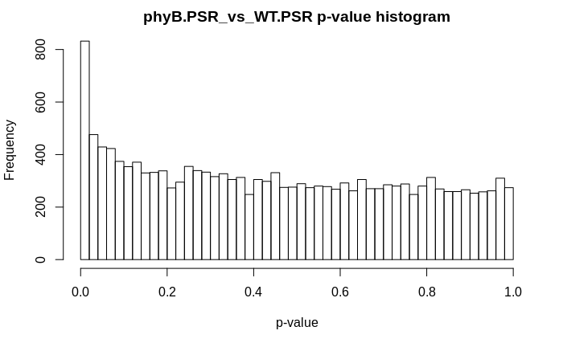

```r
dev.off()
```

```r
# --- specific --- #
```

| # END MAIN ANALYSIS |
| --- |

```r
#plot.new()
#tripVenn(DEGsRvS, DEGsR, DEGsS, c("RvsS (WT+phyB)", "R (WTvs.phyB)", "S (WTvs.phyB)"))

nVenn(list("RvsS (WT+phyB)"=row.names(DEGsRvS), "R (WTvs.phyB)"=row.names(DEGsR),
           "S (WTvs.phyB)"=row.names(DEGsS)))

#plot.new()
#tripVenn(DEGsSvP, DEGsS, DEGsP, c("SvsP (WT+phyB)", "S (WTvs.phyB)", "P (WTvs.phyB)"))

nVenn(list("SvsP (WT+phyB)"=row.names(DEGsSvP), "S (WTvs.phyB)"=row.names(DEGsS),
           "P (WTvs.phyB)"=row.names(DEGsP)))
```

# PCA

```r
cpmData <- cpm(DGEdata)
cpmData <- cpmData[, !grepl("24$", colnames(cpmData))]
pcaData <- cpmData

pca <- prcomp(t(pcaData), scale=TRUE)



plotData <- as.data.frame(pca$x)
plotData$sample <- row.names(plotData)
plotData <- tidyr::separate(plotData, sample, into=c("genotype", "plant", "treatment"), sep="_", remove=FALSE)
plotData$group <- paste(plotData$genotype, plotData$treatment, sep="_")

Palette <- c("#68d53f", "#c7dd27", "#c6874e", "red")

ggplot(plotData, aes(x=PC1, y=PC2, color=treatment, shape=genotype)) +
  geom_point(size=4) + scale_colour_manual(values=Palette)
```

```r
ggplot(plotData, aes(x=PC2, y=PC3, color=treatment, shape=genotype)) +
  geom_point(size=4) + scale_colour_manual(values=Palette)
```

```r
theta = -0.33*pi
#theta = 0.4*pi

plotData$PC2.3A <- plotData$PC3*sin(theta) + plotData$PC2*cos(theta)
plotData$PC2.3B <- plotData$PC3*cos(theta) - plotData$PC2*sin(theta)

ggplot(plotData, aes(x=PC1, y=PC2.3A, color=treatment, shape=genotype)) +
  geom_point(size=4) + scale_colour_manual(values=Palette)

newPCs <- data.frame("PC2.3A" = pca$rotation[, 3]*sin(theta) +
                       pca$rotation[, 2]*cos(theta),
                     "PC2.3B"=pca$rotation[, 3]*cos(theta) -
                       pca$rotation[, 2]*sin(theta),
                     row.names=row.names(pca$rotation))
```

```r
PC2.3sdev <- data.frame("PC" = c(2,3), "sdev"=c(
  sqrt((pca$sdev[3]*sin(theta))^2 + (pca$sdev[2]*cos(theta))^2),
  sqrt((pca$sdev[3]*cos(theta))^2 + (pca$sdev[2]*sin(theta))^2)
))

sdevData <- data.frame("PC" = 1:length(pca$sdev), "sdev"=pca$sdev)





ggplot() + geom_point(data=sdevData, aes(x=PC, y=sdev,
                                         colour="Principal Components"), size=4) +
  geom_point(data=PC2.3sdev, aes(x=PC, y=sdev, color="PC2.3 rotation"), size=4) +
  labs(title="Standard deviation of principal components")

# plot(x=1:length(pca$sdev), y=pca$sdev)
```

### do a PCA with only genes listed as “Yes” for Leaf_development

```r
leafDevGenes <- subset(edinburghGeneInfo, Leaf_development=="YES")$Gene_ID
leafDevGenes <- leafDevGenes[leafDevGenes %in% row.names(pcaData)]

leafPcaData <- pcaData[leafDevGenes, ]

pca <- prcomp(t(leafPcaData), scale=TRUE)

plotData <- as.data.frame(pca$x)
plotData$sample <- row.names(plotData)
plotData <- tidyr::separate(plotData, sample, into=c("genotype", "plant#", "treatment"), sep="_", remove=FALSE)
plotData$group <- paste(plotData$genotype, plotData$treatment, sep="_")

Palette <- c("#68d53f", "#c7dd27", "#c6874e")

ggplot(plotData, aes(x=PC1, y=PC2, color=treatment, shape=genotype)) +
  geom_point(size=4) + scale_colour_manual(values=Palette)
```

```r
ggplot(plotData, aes(x=PC2, y=PC3, color=treatment, shape=genotype)) +
  geom_point(size=4) + scale_colour_manual(values=Palette)
```

```r
theta = -0.28*pi

plotData$PC2.3A <- plotData$PC3*sin(theta) + plotData$PC2*cos(theta)

ggplot(plotData, aes(x=PC1, y=PC2.3A, color=treatment, shape=genotype)) +
  geom_point(size=4) + scale_colour_manual(values=Palette)
```

```r
plot(x=1:length(pca$sdev), y=pca$sdev)
```